# Delayed recall

# 1 Description of DataSchema variable

The description of harmonised variable is the following:

- Short name: `cog_del`
- Variable label: `Cognition - delayed recall`
- Variable description: `Test that assesses delayed recall using the common nouns from the list previously employed for measuring Immediate recall. Variable dichotomised by first quartil with value 0 and higher with value 1.`
- Domain: `Health status and functional limitations`
- Value type: `categorical`
- Category coding:

| **Code** | **Category Label** |
| --- | --- |
| 0 | <=25% |
| 1 | >25% |

- Category missings:

| **Code** | **Category Label** |
| --- | --- |
| 991 | CAPI/interviewer error |
| 992 | Impute |
| 993 | Disable to measure |
| 994 | Not attempt/not done |
| 995 | Does not answer |
| 996 | Not applicable |
| 997 | Refuse |
| 998 | Do not know |
| 999 | Missing |

- Short name: `cog_del_c`
- Variable label: `Cognition - delayed recall. Continuous variable.`
- Variable description: `Test that assesses delayed recall using the common nouns from the list previously employed for measuring Immediate recall. The total number of words correctly recalled after a delay.`
- Domain: `Health status and functional limitations`
- Value type: `continuous`
- Category missings:

| **Code** | **Category Label** |
| --- | --- |
| 991 | CAPI/interviewer error |
| 992 | Impute |
| 993 | Disable to measure |
| 994 | Not attempt/not done |
| 995 | Does not answer |
| 996 | Not applicable |
| 997 | Refuse |
| 998 | Do not know |
| 999 | Missing |

# 2 Data process

## 2.1 England

### 2.1.1 Wave 1

#### 2.1.1.1 Study-specific variable description

| **Name** | `cflisd` |
| --- | --- |
| **Label** | `Record number of words correctly remembered after delay here.` |
| **Table name** | `wave_1_core_data_v3` |
| **Measure** | `Continuous Variable 0-10` |
| **Missings** | `-9 = Refusal` `-8 = Don't know` `-1 = Not applicable` |
| **Description** |  |

Delayed recall continuous

| Sample size | Missing values |
| --- | --- |
| 12099 | 398 |

Values

|  | No-missings | -1 | -8 | -9 | NA |
| --- | --- | --- | --- | --- | --- |
| Frequency | 11701.00 | 295.00 | 19.00 | 84.00 | 0 |
| Percentage | 96.71 | 2.44 | 0.16 | 0.69 | 0 |

Summary

| Min. | 1st Qu. | Median | Mean | 3rd Qu. | Max. |
| --- | --- | --- | --- | --- | --- |
| 0 | 3 | 4 | 4.01 | 5 | 10 |

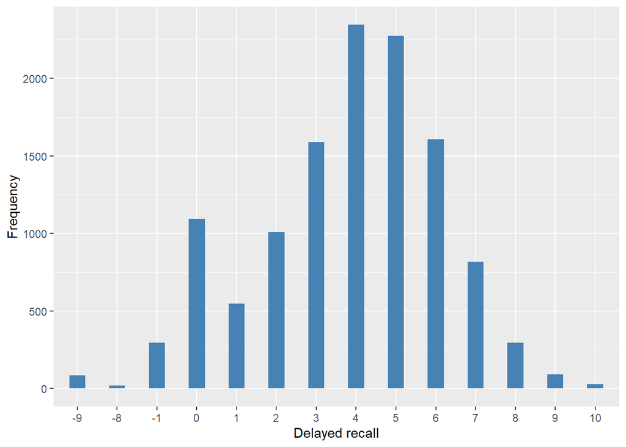

#### 2.1.1.2 Harmonisation algorithm

To compute the harmonized variable `cog_del_c` from the study-specific variables you have to sum the total of words and the missing values have to be recoded as follows:

- `-9 Refusal into 997`
- `-8 Don't know into 998`
- `-1 Not applicable into 996`
- `NA into 999`

To compute the harmonized variable `cog_del` from `cog_del_c` it has to be recoded as follows:

- `cog_del_c <=25% into 0`
- `cog_del_c >25% into 1`

**R script**

```r
## cog_del_c
ELSA_ds_w1 <- tibble(id = ELSA_w1_cog_del$id)
ELSA_ds_w1$cog_del_c <- car::recode(ELSA_w1_cog_del$cflisd, "-9 = '997';-8 = '998';-1 = '996' ")
ELSA_ds_w1$cog_del_c <- labelled(ELSA_ds_w1$cog_del_c, labels = c(Missing = 999,
    Do_not_know = 998, Refuse = 997, Not_applicable = 996, Does_not_answer = 995,
    Not_attempt_not_done = 994, Disable_to_measure = 993, Impute = 992, CAPI_interviewer_error = 991))

## cog_del
Q <- quantile(car::recode(ELSA_ds_w1$cog_del_c, "999=NA;996=NA;997=NA;998=NA"),
    probs = 1/4, na.rm = TRUE, names = FALSE)

ELSA_ds_w1$cog_del <- car::recode(ELSA_ds_w1[[2]], "0:Q=0; (Q+1):10=1")
ELSA_ds_w1$cog_del <- labelled(ELSA_ds_w1[[3]], labels = c(`<=25%` = 0, `>25%` = 1,
    Missing = 999, `Do not know` = 998, Refuse = 997, `Not applicable` = 996,
    `Does not answer` = 995, `Not attempt not done` = 994, `Disable to measure` = 993,
    Impute = 992, `CAPI interviewer error` = 991))
```

#### 2.1.1.3 Statistical description of the new harmonised variable

Test that assesses delayed recall using the common nouns from the list previously employed for measuring Immediate recall. The total number of words correctly recalled after a delay

| Sample size | Missing values |
| --- | --- |
| 12099 | 398 |

Values

|  | No-missings | 991 | 992 | 993 | 994 | 995 | 996 | 997 | 998 | 999 | NA |
| --- | --- | --- | --- | --- | --- | --- | --- | --- | --- | --- | --- |
| Frequency | 11701.00 | 0 | 0 | 0 | 0 | 0 | 295.00 | 84.00 | 19.00 | 0 | 0 |
| Percentage | 96.71 | 0 | 0 | 0 | 0 | 0 | 2.44 | 0.69 | 0.16 | 0 | 0 |

Summary

| Min. | 1st Qu. | Median | Mean | 3rd Qu. | Max. |
| --- | --- | --- | --- | --- | --- |
| 0 | 3 | 4 | 4.01 | 5 | 10 |

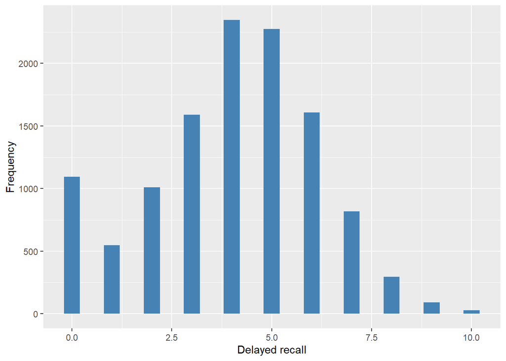

Test that assesses delayed recall using the common nouns from the list previously employed for measuring Immediate recall. Variable dichotomised by first quartil with value 0 and higher with value 1

| Sample size | Missing values |
| --- | --- |
| 12099 | 398 |

Category

|  | 0 | 1 |
| --- | --- | --- |
| Frequency | 4242.00 | 7459.00 |
| Percentage | 35.06 | 61.65 |

Type of missing

|  | 991 | 992 | 993 | 994 | 995 | 996 | 997 | 998 | 999 | NA |
| --- | --- | --- | --- | --- | --- | --- | --- | --- | --- | --- |
| Frequency | 0 | 0 | 0 | 0 | 0 | 295.00 | 84.00 | 19.00 | 0 | 0 |
| Percentage | 0 | 0 | 0 | 0 | 0 | 2.44 | 0.69 | 0.16 | 0 | 0 |

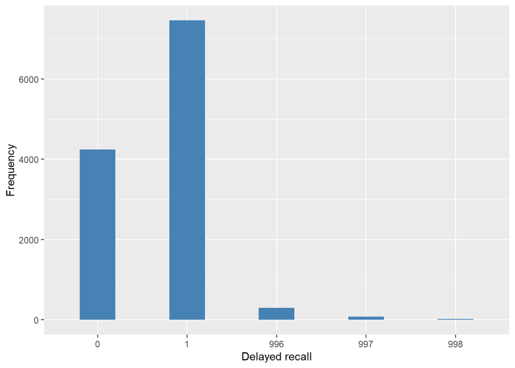

#### 2.1.1.4 Validation

Continuous vs Dichotomous

|  | 0:3->0 | 4:10->1 | -1->996 | -9->997 | -8->998 |
| --- | --- | --- | --- | --- | --- |
| continuous | 4242 | 7459 | 295 | 84 | 19 |
| dichotomous | 4242 | 7459 | 295 | 84 | 19 |

### 2.1.2 Wave 2

#### 2.1.2.1 Study-specific variable description

| **Name** | `CfLisD` |
| --- | --- |
| **Label** | `Number of words recalled after a delay` |
| **Table name** | `wave_2_core_data_v4` |
| **Measure** | `Continuous Variable 0-10` |
| **Missings** | `-9 = Refusal` `-8 = Don't know` `-1 = Not applicable` |
| **Description** |  |

Immediate recall continuous

| Sample size | Missing values |
| --- | --- |
| 9432 | 183 |

Values

|  | No-missings | -9 | -8 | -1 | NA |
| --- | --- | --- | --- | --- | --- |
| Frequency | 9249.00 | 16.00 | 13.00 | 154.00 | 0 |
| Percentage | 98.06 | 0.17 | 0.14 | 1.63 | 0 |

Summary

| Min. | 1st Qu. | Median | Mean | 3rd Qu. | Max. |
| --- | --- | --- | --- | --- | --- |
| 0 | 3 | 4 | 4.283 | 6 | 10 |

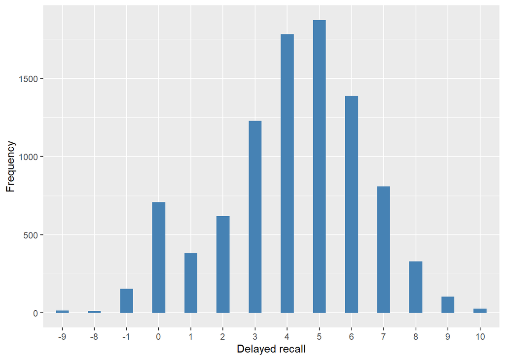

#### 2.1.2.2 Harmonisation algorithm

To compute the harmonized variable `cog_del_c` from the study-specific variables you have to sum the total of words and the missing values have to be recoded as follows:

- `-9 Refusal into 997`
- `-8 Don't know into 998`
- `-1 Not applicable into 996`
- `NA into 999`

To compute the harmonized variable `cog_del` from `cog_del_c` it has to be recoded as follows:

- `cog_del_c <=25% into 0`
- `cog_del_c >25% into 1`

**R script**

```r
## cog_del_c
ELSA_ds_w2 <- tibble(id = ELSA_w2_cog_del$id)
ELSA_ds_w2$cog_del_c <- car::recode(ELSA_w2_cog_del$CfLisD, "-9 = 997; -8 = 998; -1 = 996")
ELSA_ds_w2$cog_del_c <- labelled(ELSA_ds_w2$cog_del_c, labels = c(Missing = 999,
    Do_not_know = 998, Refuse = 997, Not_applicable = 996, Does_not_answer = 995,
    Not_attempt_not_done = 994, Disable_to_measure = 993, Impute = 992, CAPI_interviewer_error = 991))

## cog_del
Q <- quantile(car::recode(ELSA_ds_w2$cog_del_c, "999=NA;997=NA;996=NA;998=NA"),
    probs = 1/4, na.rm = TRUE, names = FALSE)

ELSA_ds_w2$cog_del <- car::recode(ELSA_ds_w2[[2]], "0:Q=0; (Q+1):10=1")
ELSA_ds_w2$cog_del <- labelled(ELSA_ds_w2[[3]], labels = c(`<=25%` = 0, `>25%` = 1,
    Missing = 999, `Do not know` = 998, Refuse = 997, `Not applicable` = 996,
    `Does not answer` = 995, `Not attempt not done` = 994, `Disable to measure` = 993,
    Impute = 992, `CAPI interviewer error` = 991))
```

#### 2.1.2.3 Statistical description of the new harmonised variable

Test that assesses delayed recall using the common nouns from the list previously employed for measuring Immediate recall. The total number of words correctly recalled after a delay

| Sample size | Missing values |
| --- | --- |
| 9432 | 183 |

Values

|  | No-missings | 991 | 992 | 993 | 994 | 995 | 996 | 997 | 998 | 999 | NA |
| --- | --- | --- | --- | --- | --- | --- | --- | --- | --- | --- | --- |
| Frequency | 9249.00 | 0 | 0 | 0 | 0 | 0 | 154.00 | 16.00 | 13.00 | 0 | 0 |
| Percentage | 98.06 | 0 | 0 | 0 | 0 | 0 | 1.63 | 0.17 | 0.14 | 0 | 0 |

Summary

| Min. | 1st Qu. | Median | Mean | 3rd Qu. | Max. |
| --- | --- | --- | --- | --- | --- |
| 0 | 3 | 4 | 4.283 | 6 | 10 |

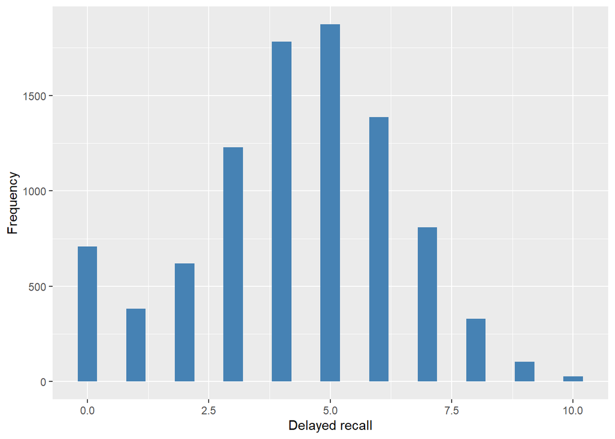

Test that assesses delayed recall using the common nouns from the list previously employed for measuring Immediate recall. Variable dichotomised by first quartil with value 0 and higher with value 1

| Sample size | Missing values |
| --- | --- |
| 9432 | 183 |

Category

|  | 0 | 1 |
| --- | --- | --- |
| Frequency | 2939.00 | 6310.0 |
| Percentage | 31.16 | 66.9 |

Type of missing

|  | 991 | 992 | 993 | 994 | 995 | 996 | 997 | 998 | 999 | NA |
| --- | --- | --- | --- | --- | --- | --- | --- | --- | --- | --- |
| Frequency | 0 | 0 | 0 | 0 | 0 | 154.00 | 16.00 | 13.00 | 0 | 0 |
| Percentage | 0 | 0 | 0 | 0 | 0 | 1.63 | 0.17 | 0.14 | 0 | 0 |

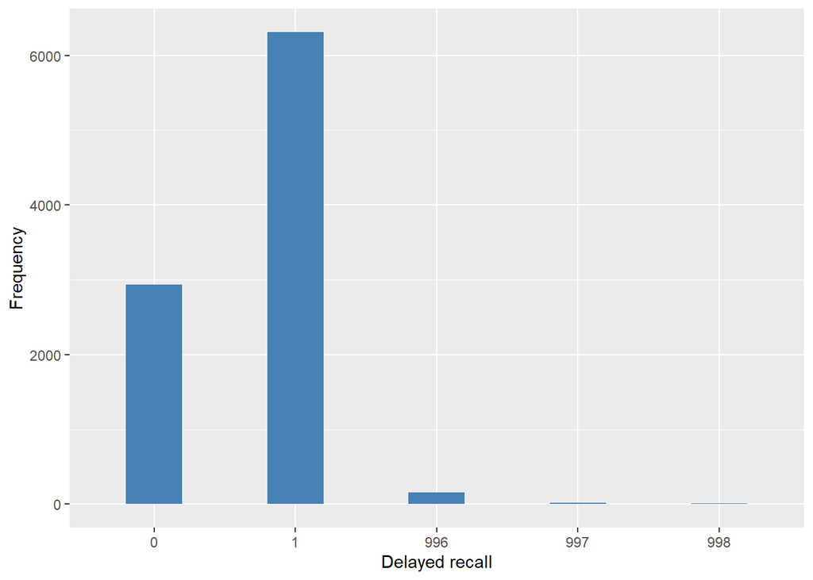

#### 2.1.2.4 Validation

Continuous vs Dichotomous

|  | 0:3->0 | 4:10->1 | -1->996 | -9->997 | -8->998 |
| --- | --- | --- | --- | --- | --- |
| continuous | 2939 | 6310 | 154 | 16 | 13 |
| dichotomous | 2939 | 6310 | 154 | 16 | 13 |

### 2.1.3 Wave 3

#### 2.1.3.1 Study-specific variable description

| **Name** | `cflisd` |
| --- | --- |
| **Label** | `Number of words recalled after a delay` |
| **Table name** | `wave_3_elsa_data_v4` |
| **Measure** | `Continuous Variable 0-10` |
| **Missings** | `-9 = Refusal` `-1 = Not applicable` |
| **Description** |  |

Immediate recall continuous

| Sample size | Missing values |
| --- | --- |
| 9771 | 279 |

Values

|  | No-missings | -9 | -1 | NA |
| --- | --- | --- | --- | --- |
| Frequency | 9492.00 | 8.00 | 271.00 | 0 |
| Percentage | 97.14 | 0.08 | 2.77 | 0 |

Summary

| Min. | 1st Qu. | Median | Mean | 3rd Qu. | Max. |
| --- | --- | --- | --- | --- | --- |
| 0 | 3 | 5 | 4.53 | 6 | 10 |

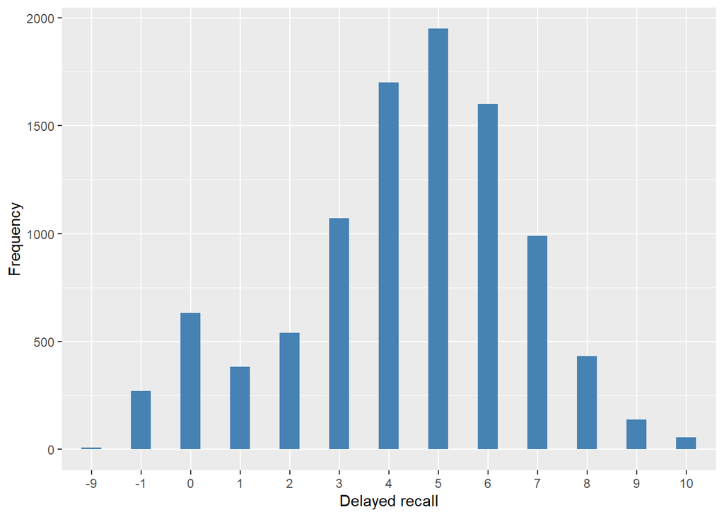

#### 2.1.3.2 Harmonisation algorithm

To compute the harmonized variable `cog_del_c` from the study-specific variables you have to sum the total of words and the missing values have to be recoded as follows:

- `-9 Refusal into 997`
- `-1 Not applicable into 996`
- `NA into 999`

To compute the harmonized variable `cog_del` from `cog_del_c` it has to be recoded as follows:

- `cog_del_c <=25% into 0`
- `cog_del_c >25% into 1`

**R script**

```r
## cog_del_c
ELSA_ds_w3 <- tibble(id = ELSA_w3_cog_del$id)
ELSA_ds_w3$cog_del_c <- car::recode(ELSA_w3_cog_del$cflisd, "-9 = 997; -1 = 996")
ELSA_ds_w3$cog_del_c <- labelled(ELSA_ds_w3$cog_del_c, labels = c(Missing = 999,
    Do_not_know = 998, Refuse = 997, Not_applicable = 996, Does_not_answer = 995,
    Not_attempt_not_done = 994, Disable_to_measure = 993, Impute = 992, CAPI_interviewer_error = 991))

## cog_del
Q <- quantile(car::recode(ELSA_ds_w3$cog_del_c, "999=NA;997=NA;996=NA"), probs = 1/4,
    na.rm = TRUE, names = FALSE)

ELSA_ds_w3$cog_del <- car::recode(ELSA_ds_w3[[2]], "0:Q=0; (Q+1):10=1")
ELSA_ds_w3$cog_del <- labelled(ELSA_ds_w3[[3]], labels = c(`<=25%` = 0, `>25%` = 1,
    Missing = 999, `Do not know` = 998, Refuse = 997, `Not applicable` = 996,
    `Does not answer` = 995, `Not attempt not done` = 994, `Disable to measure` = 993,
    Impute = 992, `CAPI interviewer error` = 991))
```

#### 2.1.3.3 Statistical description of the new harmonised variable

Test that assesses delayed recall using the common nouns from the list previously employed for measuring Immediate recall. The total number of words correctly recalled after a delay

| Sample size | Missing values |
| --- | --- |
| 9771 | 279 |

Values

|  | No-missings | 991 | 992 | 993 | 994 | 995 | 996 | 997 | 998 | 999 | NA |
| --- | --- | --- | --- | --- | --- | --- | --- | --- | --- | --- | --- |
| Frequency | 9492.00 | 0 | 0 | 0 | 0 | 0 | 271.00 | 8.00 | 0 | 0 | 0 |
| Percentage | 97.14 | 0 | 0 | 0 | 0 | 0 | 2.77 | 0.08 | 0 | 0 | 0 |

Summary

| Min. | 1st Qu. | Median | Mean | 3rd Qu. | Max. |
| --- | --- | --- | --- | --- | --- |
| 0 | 3 | 5 | 4.53 | 6 | 10 |

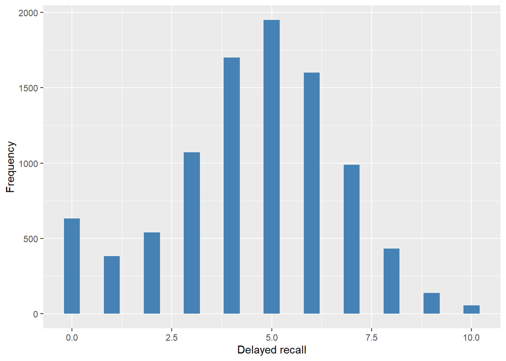

Test that assesses delayed recall using the common nouns from the list previously employed for measuring Immediate recall. Variable dichotomised by first quartil with value 0 and higher with value 1

| Sample size | Missing values |
| --- | --- |
| 9771 | 279 |

Category

|  | 0 | 1 |
| --- | --- | --- |
| Frequency | 2627.00 | 6865.00 |
| Percentage | 26.89 | 70.26 |

Type of missing

|  | 991 | 992 | 993 | 994 | 995 | 996 | 997 | 998 | 999 | NA |
| --- | --- | --- | --- | --- | --- | --- | --- | --- | --- | --- |
| Frequency | 0 | 0 | 0 | 0 | 0 | 271.00 | 8.00 | 0 | 0 | 0 |
| Percentage | 0 | 0 | 0 | 0 | 0 | 2.77 | 0.08 | 0 | 0 | 0 |

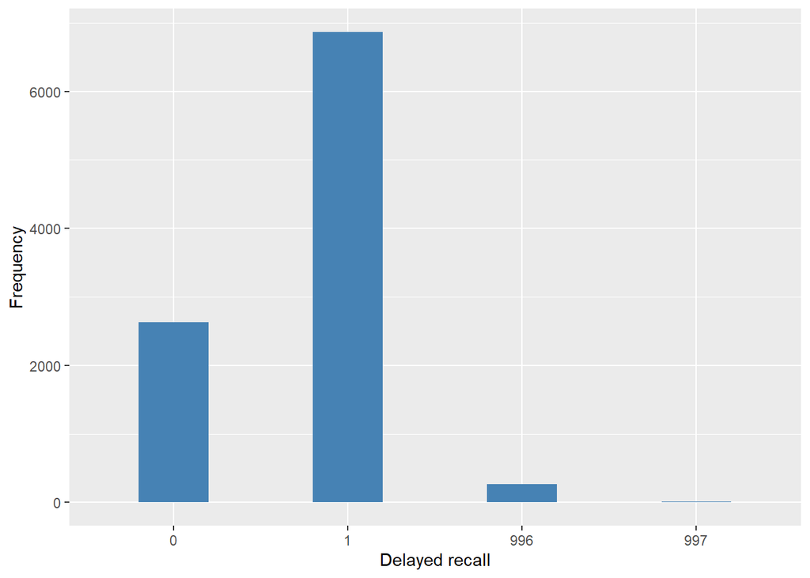

#### 2.1.3.4 Validation

Continuous vs Dichotomous

|  | 0:3->0 | 4:10->1 | -1->996 | -9->997 |
| --- | --- | --- | --- | --- |
| continuous | 2627 | 6865 | 271 | 8 |
| dichotomous | 2627 | 6865 | 271 | 8 |

### 2.1.4 Wave 4

#### 2.1.4.1 Study-specific variable description

| **Name** | `cflisd` |
| --- | --- |
| **Label** | `Number of words recalled after a delay` |
| **Table name** | `wave_4_elsa_data_v3` |
| **Measure** | `Continuous Variable 0-10` |
| **Missings** | `-9 = Refusal` `-1 = Not applicable` |
| **Description** |  |

Immediate recall continuous

| Sample size | Missing values |
| --- | --- |
| 11050 | 479 |

Values

|  | No-missings | -9 | -1 | NA |
| --- | --- | --- | --- | --- |
| Frequency | 10571.00 | 33.0 | 446.00 | 0 |
| Percentage | 95.67 | 0.3 | 4.04 | 0 |

Summary

| Min. | 1st Qu. | Median | Mean | 3rd Qu. | Max. |
| --- | --- | --- | --- | --- | --- |
| 0 | 3 | 5 | 4.566 | 6 | 10 |

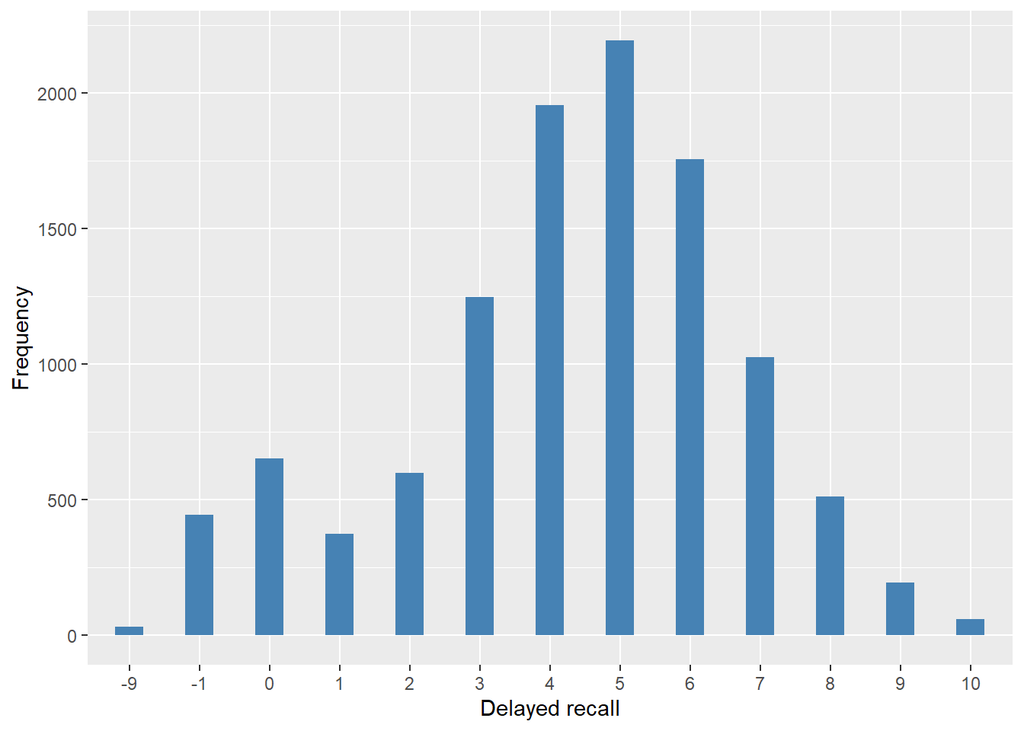

#### 2.1.4.2 Harmonisation algorithm

To compute the harmonized variable `cog_del_c` from the study-specific variables you have to sum the total of words and the missing values have to be recoded as follows:

- `-9 Refusal into 997`
- `-1 Not applicable into 996`
- `NA into 999`

To compute the harmonized variable `cog_del` from `cog_del_c` it has to be recoded as follows:

- `cog_del_c <=25% into 0`
- `cog_del_c >25% into 1`

**R script**

```r
## cog_del_c
ELSA_ds_w4 <- tibble(id = ELSA_w4_cog_del$id)
ELSA_ds_w4$cog_del_c <- car::recode(ELSA_w4_cog_del$cflisd, "-9 = 997; -1 = 996")
ELSA_ds_w4$cog_del_c <- labelled(ELSA_ds_w4$cog_del_c, labels = c(Missing = 999,
    Do_not_know = 998, Refuse = 997, Not_applicable = 996, Does_not_answer = 995,
    Not_attempt_not_done = 994, Disable_to_measure = 993, Impute = 992, CAPI_interviewer_error = 991))

## cog_del
Q <- quantile(car::recode(ELSA_ds_w4$cog_del_c, "999=NA;997=NA;996=NA"), probs = 1/4,
    na.rm = TRUE, names = FALSE)

ELSA_ds_w4$cog_del <- car::recode(ELSA_ds_w4[[2]], "0:Q=0; (Q+1):10=1")
ELSA_ds_w4$cog_del <- labelled(ELSA_ds_w4[[3]], labels = c(`<=25%` = 0, `>25%` = 1,
    Missing = 999, `Do not know` = 998, Refuse = 997, `Not applicable` = 996,
    `Does not answer` = 995, `Not attempt not done` = 994, `Disable to measure` = 993,
    Impute = 992, `CAPI interviewer error` = 991))
```

#### 2.1.4.3 Statistical description of the new harmonised variable

Test that assesses delayed recall using the common nouns from the list previously employed for measuring Immediate recall. The total number of words correctly recalled after a delay

| Sample size | Missing values |
| --- | --- |
| 11050 | 479 |

Values

|  | No-missings | 991 | 992 | 993 | 994 | 995 | 996 | 997 | 998 | 999 | NA |
| --- | --- | --- | --- | --- | --- | --- | --- | --- | --- | --- | --- |
| Frequency | 10571.00 | 0 | 0 | 0 | 0 | 0 | 446.00 | 33.0 | 0 | 0 | 0 |
| Percentage | 95.67 | 0 | 0 | 0 | 0 | 0 | 4.04 | 0.3 | 0 | 0 | 0 |

Summary

| Min. | 1st Qu. | Median | Mean | 3rd Qu. | Max. |
| --- | --- | --- | --- | --- | --- |
| 0 | 3 | 5 | 4.566 | 6 | 10 |

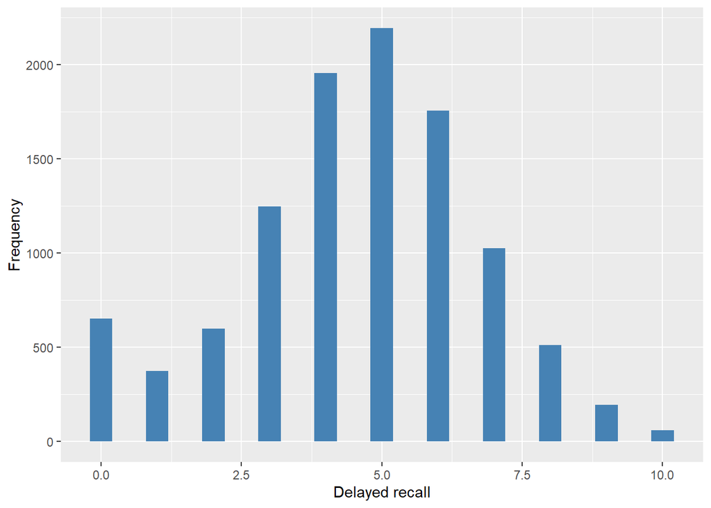

Test that assesses delayed recall using the common nouns from the list previously employed for measuring Immediate recall. Variable dichotomised by first quartil with value 0 and higher with value 1

| Sample size | Missing values |
| --- | --- |
| 11050 | 479 |

Category

|  | 0 | 1 |
| --- | --- | --- |
| Frequency | 2874.00 | 7697.00 |
| Percentage | 26.01 | 69.66 |

Type of missing

|  | 991 | 992 | 993 | 994 | 995 | 996 | 997 | 998 | 999 | NA |
| --- | --- | --- | --- | --- | --- | --- | --- | --- | --- | --- |
| Frequency | 0 | 0 | 0 | 0 | 0 | 446.00 | 33.0 | 0 | 0 | 0 |
| Percentage | 0 | 0 | 0 | 0 | 0 | 4.04 | 0.3 | 0 | 0 | 0 |

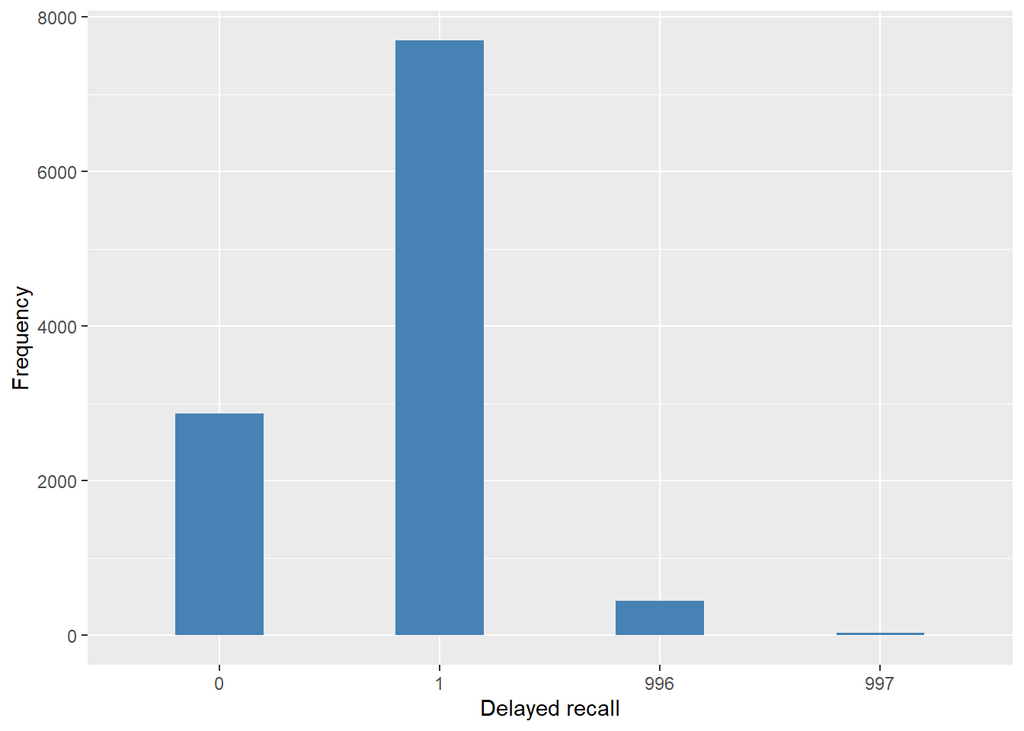

#### 2.1.4.4 Validation

Continuous vs Dichotomous

|  | 0:3->0 | 4:10->1 | -1->996 | -9->997 |
| --- | --- | --- | --- | --- |
| continuous | 2874 | 7697 | 446 | 33 |
| dichotomous | 2874 | 7697 | 446 | 33 |

### 2.1.5 Wave 5

#### 2.1.5.1 Study-specific variable description

| **Name** | `cflisd` |
| --- | --- |
| **Label** | `Number of words recalled after a delay` |
| **Table name** | `wave_5_elsa_data_v4` |
| **Measure** | `Continuous Variable 0-10` |
| **Missings** | `-9 = Refusal` `-1 = Not applicable` |
| **Description** |  |

Immediate recall continuous

| Sample size | Missing values |
| --- | --- |
| 10274 | 585 |

Values

|  | No-missings | -9 | -1 | NA |
| --- | --- | --- | --- | --- |
| Frequency | 9689.00 | 48.00 | 537.00 | 0 |
| Percentage | 94.31 | 0.47 | 5.23 | 0 |

Summary

| Min. | 1st Qu. | Median | Mean | 3rd Qu. | Max. |
| --- | --- | --- | --- | --- | --- |
| 0 | 3 | 5 | 4.587 | 6 | 10 |

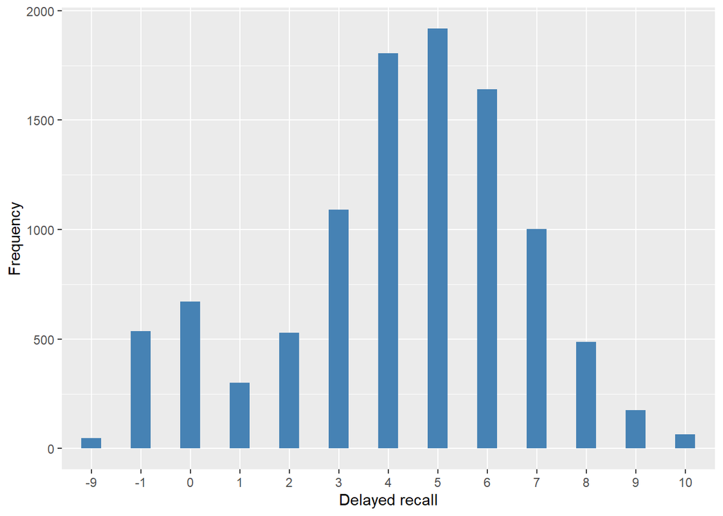

#### 2.1.5.2 Harmonisation algorithm

To compute the harmonized variable `cog_del_c` from the study-specific variables you have to sum the total of words and the missing values have to be recoded as follows:

- `-9 Refusal into 997`
- `-1 Not applicable into 996`
- `NA into 999`

To compute the harmonized variable `cog_del` from `cog_del_c` it has to be recoded as follows:

- `cog_del_c <=25% into 0`
- `cog_del_c >25% into 1`

**R script**

```r
## cog_del_c
ELSA_ds_w5 <- tibble(id = ELSA_w5_cog_del$id)
ELSA_ds_w5$cog_del_c <- car::recode(ELSA_w5_cog_del$cflisd, "-9 = 997;-1 = 996")
ELSA_ds_w5$cog_del_c <- labelled(ELSA_ds_w5$cog_del_c, labels = c(Missing = 999,
    Do_not_know = 998, Refuse = 997, Not_applicable = 996, Does_not_answer = 995,
    Not_attempt_not_done = 994, Disable_to_measure = 993, Impute = 992, CAPI_interviewer_error = 991))

## cog_del
Q <- quantile(car::recode(ELSA_ds_w5$cog_del_c, "999=NA;997=NA;996=NA"), probs = 1/4,
    na.rm = TRUE, names = FALSE)

ELSA_ds_w5$cog_del <- car::recode(ELSA_ds_w5[[2]], "0:Q=0; (Q+1):10=1")
ELSA_ds_w5$cog_del <- labelled(ELSA_ds_w5[[3]], labels = c(`<=25%` = 0, `>25%` = 1,
    Missing = 999, `Do not know` = 998, Refuse = 997, `Not applicable` = 996,
    `Does not answer` = 995, `Not attempt not done` = 994, `Disable to measure` = 993,
    Impute = 992, `CAPI interviewer error` = 991))
```

#### 2.1.5.3 Statistical description of the new harmonised variable

Test that assesses delayed recall using the common nouns from the list previously employed for measuring Immediate recall. The total number of words correctly recalled after a delay

| Sample size | Missing values |
| --- | --- |
| 10274 | 585 |

Values

|  | No-missings | 991 | 992 | 993 | 994 | 995 | 996 | 997 | 998 | 999 | NA |
| --- | --- | --- | --- | --- | --- | --- | --- | --- | --- | --- | --- |
| Frequency | 9689.00 | 0 | 0 | 0 | 0 | 0 | 537.00 | 48.00 | 0 | 0 | 0 |
| Percentage | 94.31 | 0 | 0 | 0 | 0 | 0 | 5.23 | 0.47 | 0 | 0 | 0 |

Summary

| Min. | 1st Qu. | Median | Mean | 3rd Qu. | Max. |
| --- | --- | --- | --- | --- | --- |
| 0 | 3 | 5 | 4.587 | 6 | 10 |

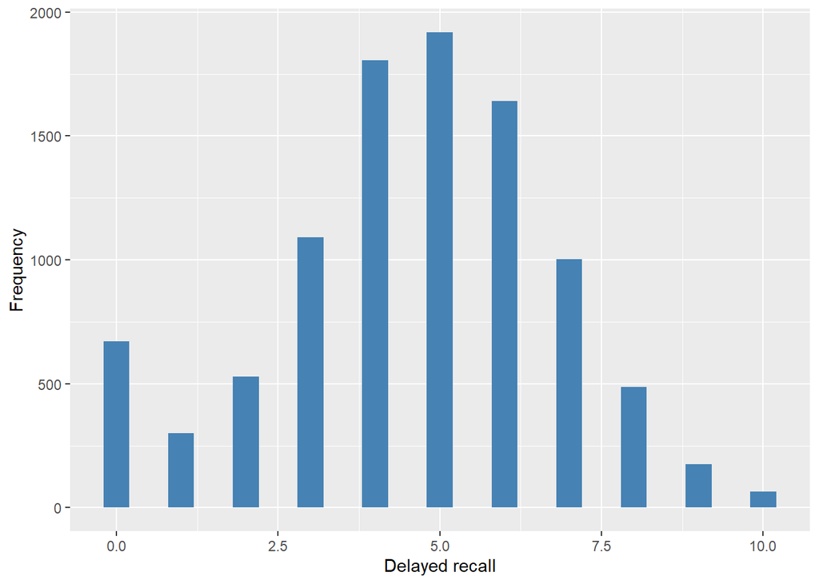

Test that assesses delayed recall using the common nouns from the list previously employed for measuring Immediate recall. Variable dichotomised by first quartil with value 0 and higher with value 1

| Sample size | Missing values |
| --- | --- |
| 10274 | 585 |

Category

|  | 0 | 1 |
| --- | --- | --- |
| Frequency | 2593.00 | 7096.00 |
| Percentage | 25.24 | 69.07 |

Type of missing

|  | 991 | 992 | 993 | 994 | 995 | 996 | 997 | 998 | 999 | NA |
| --- | --- | --- | --- | --- | --- | --- | --- | --- | --- | --- |
| Frequency | 0 | 0 | 0 | 0 | 0 | 537.00 | 48.00 | 0 | 0 | 0 |
| Percentage | 0 | 0 | 0 | 0 | 0 | 5.23 | 0.47 | 0 | 0 | 0 |

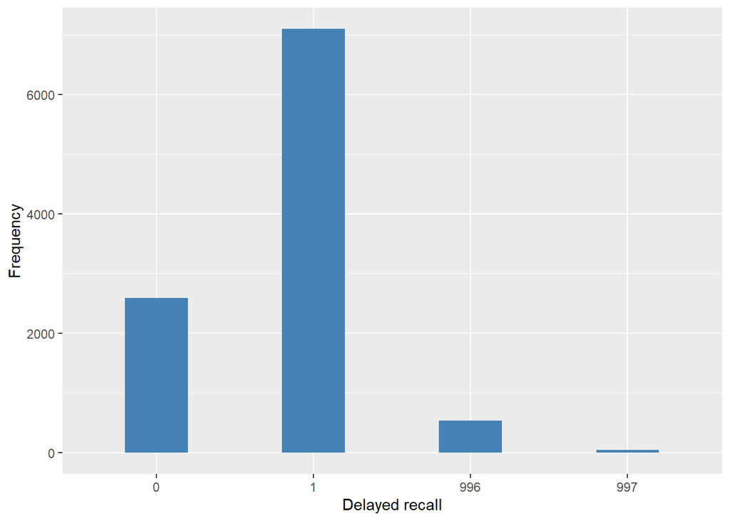

#### 2.1.5.4 Validation

Continuous vs Dichotomous

|  | 0:3->0 | 4:10->1 | -1->996 | -9->997 |
| --- | --- | --- | --- | --- |
| continuous | 2593 | 7096 | 537 | 48 |
| dichotomous | 2593 | 7096 | 537 | 48 |

### 2.1.6 Wave 6

#### 2.1.6.1 Study-specific variable description

| **Name** | `CfLisD` |
| --- | --- |
| **Label** | `Number of words recalled after a delay` |
| **Table name** | `wave_6_elsa_data_v2` |
| **Measure** | `Continuous Variable 0-10` |
| **Missings** | `-9 = Refusal` `-1 = Not applicable` |
| **Description** |  |

Immediate recall continuous

| Sample size | Missing values |
| --- | --- |
| 10601 | 629 |

Values

|  | No-missings | -9 | -1 | NA |
| --- | --- | --- | --- | --- |
| Frequency | 9972.00 | 4.00 | 625.0 | 0 |
| Percentage | 94.07 | 0.04 | 5.9 | 0 |

Summary

| Min. | 1st Qu. | Median | Mean | 3rd Qu. | Max. |
| --- | --- | --- | --- | --- | --- |
| 0 | 4 | 5 | 4.774 | 6 | 10 |

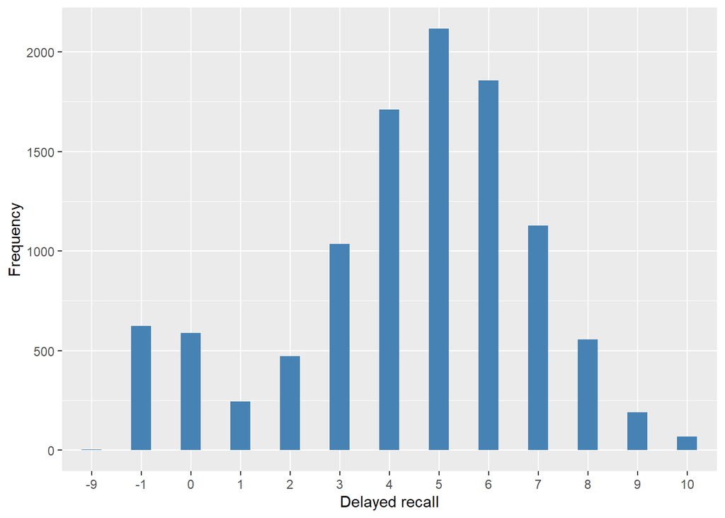

#### 2.1.6.2 Harmonisation algorithm

To compute the harmonized variable `cog_del_c` from the study-specific variables you have to sum the total of words and the missing values have to be recoded as follows:

- `-9 Refusal into 997`
- `-1 Not applicable into 996`
- `NA into 999`

To compute the harmonized variable `cog_del` from `cog_del_c` it has to be recoded as follows:

- `cog_del_c <=25% into 0`
- `cog_del_c >25% into 1`

**R script**

```r
## cog_del_c
ELSA_ds_w6 <- tibble(id = ELSA_w6_cog_del$id)
ELSA_ds_w6$cog_del_c <- car::recode(ELSA_w6_cog_del$CfLisD, "-9 = 997;-1 = 996")
ELSA_ds_w6$cog_del_c <- labelled(ELSA_ds_w6$cog_del_c, labels = c(Missing = 999,
    Do_not_know = 998, Refuse = 997, Not_applicable = 996, Does_not_answer = 995,
    Not_attempt_not_done = 994, Disable_to_measure = 993, Impute = 992, CAPI_interviewer_error = 991))

## cog_del
Q <- quantile(car::recode(ELSA_ds_w6$cog_del_c, "999=NA;997=NA;996=NA"), probs = 1/4,
    na.rm = TRUE, names = FALSE)

ELSA_ds_w6$cog_del <- car::recode(ELSA_ds_w6[[2]], "0:Q=0; (Q+1):10=1")
ELSA_ds_w6$cog_del <- labelled(ELSA_ds_w6[[3]], labels = c(`<=25%` = 0, `>25%` = 1,
    Missing = 999, `Do not know` = 998, Refuse = 997, `Not applicable` = 996,
    `Does not answer` = 995, `Not attempt not done` = 994, `Disable to measure` = 993,
    Impute = 992, `CAPI interviewer error` = 991))
```

#### 2.1.6.3 Statistical description of the new harmonised variable

Test that assesses delayed recall using the common nouns from the list previously employed for measuring Immediate recall. The total number of words correctly recalled after a delay

| Sample size | Missing values |
| --- | --- |
| 10601 | 629 |

Values

|  | No-missings | 991 | 992 | 993 | 994 | 995 | 996 | 997 | 998 | 999 | NA |
| --- | --- | --- | --- | --- | --- | --- | --- | --- | --- | --- | --- |
| Frequency | 9972.00 | 0 | 0 | 0 | 0 | 0 | 625.0 | 4.00 | 0 | 0 | 0 |
| Percentage | 94.07 | 0 | 0 | 0 | 0 | 0 | 5.9 | 0.04 | 0 | 0 | 0 |

Summary

| Min. | 1st Qu. | Median | Mean | 3rd Qu. | Max. |
| --- | --- | --- | --- | --- | --- |
| 0 | 4 | 5 | 4.774 | 6 | 10 |

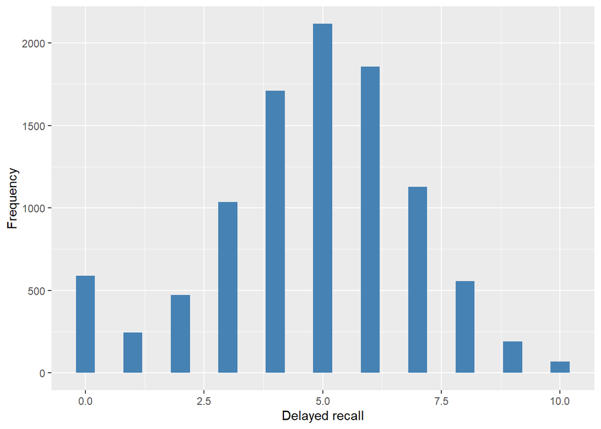

Test that assesses delayed recall using the common nouns from the list previously employed for measuring Immediate recall. Variable dichotomised by first quartil with value 0 and higher with value 1

| Sample size | Missing values |
| --- | --- |
| 10601 | 629 |

Category

|  | 0 | 1 |
| --- | --- | --- |
| Frequency | 4056.00 | 5916.00 |
| Percentage | 38.26 | 55.81 |

Type of missing

|  | 991 | 992 | 993 | 994 | 995 | 996 | 997 | 998 | 999 | NA |
| --- | --- | --- | --- | --- | --- | --- | --- | --- | --- | --- |
| Frequency | 0 | 0 | 0 | 0 | 0 | 625.0 | 4.00 | 0 | 0 | 0 |
| Percentage | 0 | 0 | 0 | 0 | 0 | 5.9 | 0.04 | 0 | 0 | 0 |

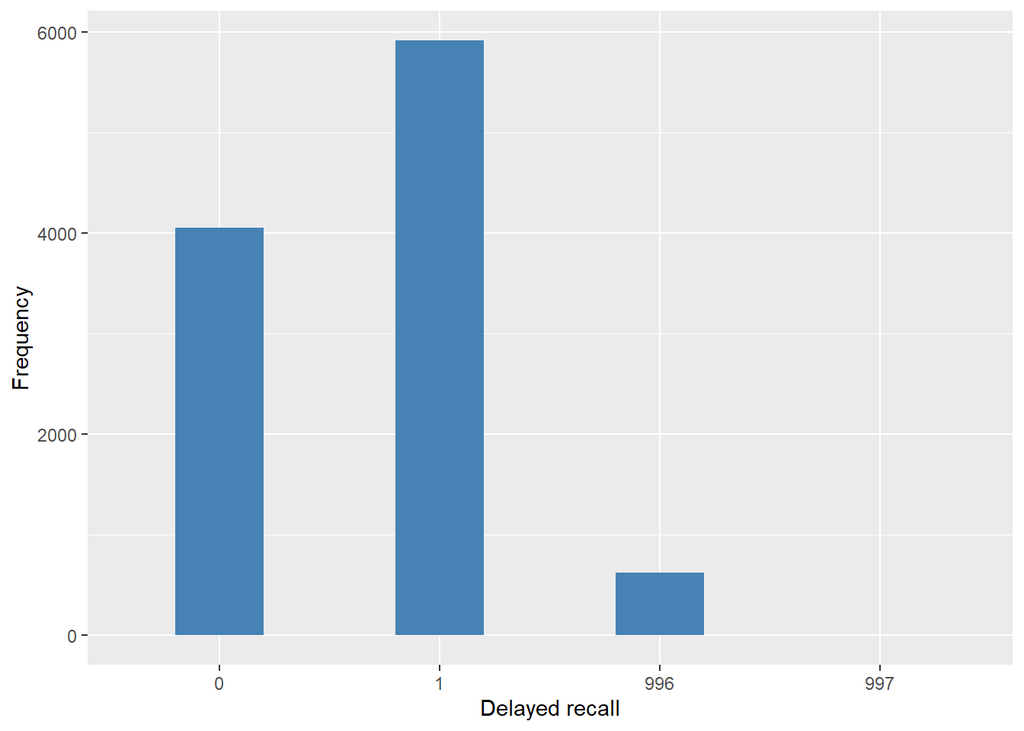

#### 2.1.6.4 Validation

Continuous vs Dichotomous

|  | 0:4->0 | 5:10->1 | -1->996 | -9->997 |
| --- | --- | --- | --- | --- |
| continuous | 4056 | 5916 | 625 | 4 |
| dichotomous | 4056 | 5916 | 625 | 4 |

### 2.1.7 Wave 7

#### 2.1.7.1 Study-specific variable description

| **Name** | `CfLisD` |
| --- | --- |
| **Label** | `Number of words recalled after a delay` |
| **Table name** | `wave_7_elsa_data` |
| **Measure** | `Continuous Variable 0-10` |
| **Missings** | `-9 = Refusal` `-1 = Not applicable` |
| **Description** |  |

Immediate recall continuous

| Sample size | Missing values |
| --- | --- |
| 9666 | 608 |

Values

|  | No-missings | -9 | -1 | NA |
| --- | --- | --- | --- | --- |
| Frequency | 9058.00 | 11.00 | 597.00 | 0 |
| Percentage | 93.71 | 0.11 | 6.18 | 0 |

Summary

| Min. | 1st Qu. | Median | Mean | 3rd Qu. | Max. |
| --- | --- | --- | --- | --- | --- |
| 0 | 3 | 5 | 4.6 | 6 | 10 |

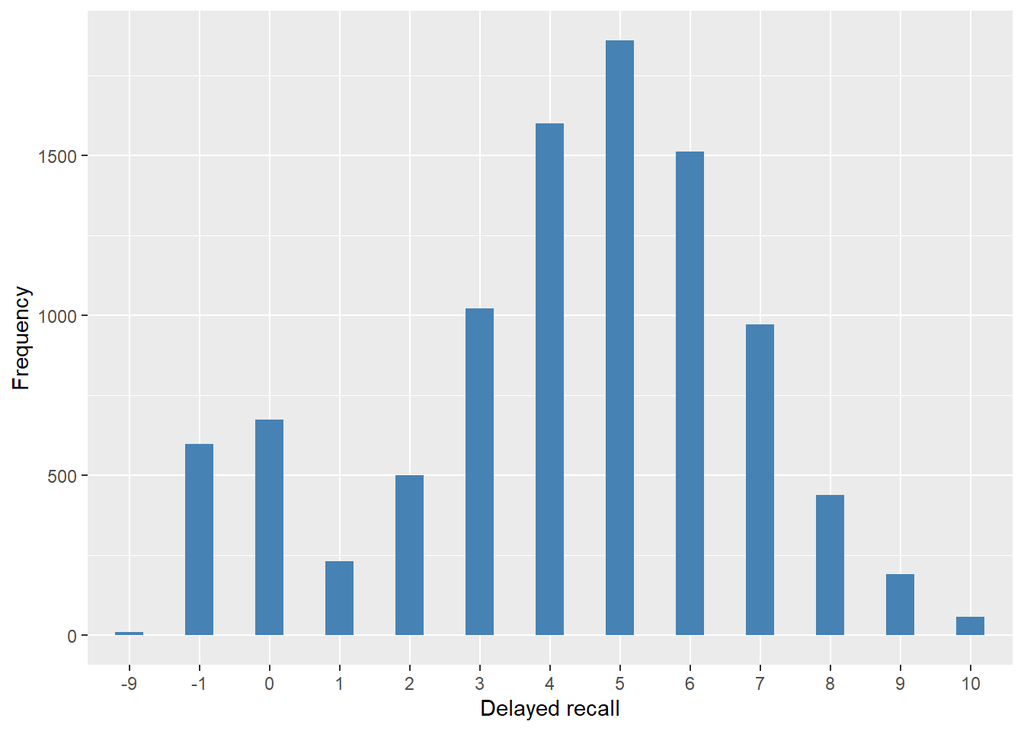

#### 2.1.7.2 Harmonisation algorithm

To compute the harmonized variable `cog_del_c` from the study-specific variables you have to sum the total of words and the missing values have to be recoded as follows:

- `-9 Refusal into 997`
- `-1 Not applicable into 996`
- `NA into 999`

To compute the harmonized variable `cog_del` from `cog_del_c` it has to be recoded as follows:

- `cog_del_c <=25% into 0`
- `cog_del_c >25% into 1`

**R script**

```r
## cog_del_c
ELSA_ds_w7 <- tibble(id = ELSA_w7_cog_del$id)
ELSA_ds_w7$cog_del_c <- car::recode(ELSA_w7_cog_del$CfLisD, "-9 = '997';-8 = '998';-1 = '996' ")
ELSA_ds_w7$cog_del_c <- labelled(ELSA_ds_w7$cog_del_c, labels = c(Missing = 999,
    Do_not_know = 998, Refuse = 997, Not_applicable = 996, Does_not_answer = 995,
    Not_attempt_not_done = 994, Disable_to_measure = 993, Impute = 992, CAPI_interviewer_error = 991))

## cog_del
Q <- quantile(car::recode(ELSA_ds_w7$cog_del_c, "999=NA;997=NA;996=NA"), probs = 1/4,
    na.rm = TRUE, names = FALSE)

ELSA_ds_w7$cog_del <- car::recode(ELSA_ds_w7[[2]], "0:Q=0; (Q+1):10=1")
ELSA_ds_w7$cog_del <- labelled(ELSA_ds_w7[[3]], labels = c(`<=25%` = 0, `>25%` = 1,
    Missing = 999, `Do not know` = 998, Refuse = 997, `Not applicable` = 996,
    `Does not answer` = 995, `Not attempt not done` = 994, `Disable to measure` = 993,
    Impute = 992, `CAPI interviewer error` = 991))
```

#### 2.1.7.3 Statistical description of the new harmonised variable

Test that assesses delayed recall using the common nouns from the list previously employed for measuring Immediate recall. The total number of words correctly recalled after a delay

| Sample size | Missing values |
| --- | --- |
| 9666 | 608 |

Values

|  | No-missings | 991 | 992 | 993 | 994 | 995 | 996 | 997 | 998 | 999 | NA |
| --- | --- | --- | --- | --- | --- | --- | --- | --- | --- | --- | --- |
| Frequency | 9058.00 | 0 | 0 | 0 | 0 | 0 | 597.00 | 11.00 | 0 | 0 | 0 |
| Percentage | 93.71 | 0 | 0 | 0 | 0 | 0 | 6.18 | 0.11 | 0 | 0 | 0 |

Summary

| Min. | 1st Qu. | Median | Mean | 3rd Qu. | Max. |
| --- | --- | --- | --- | --- | --- |
| 0 | 3 | 5 | 4.6 | 6 | 10 |

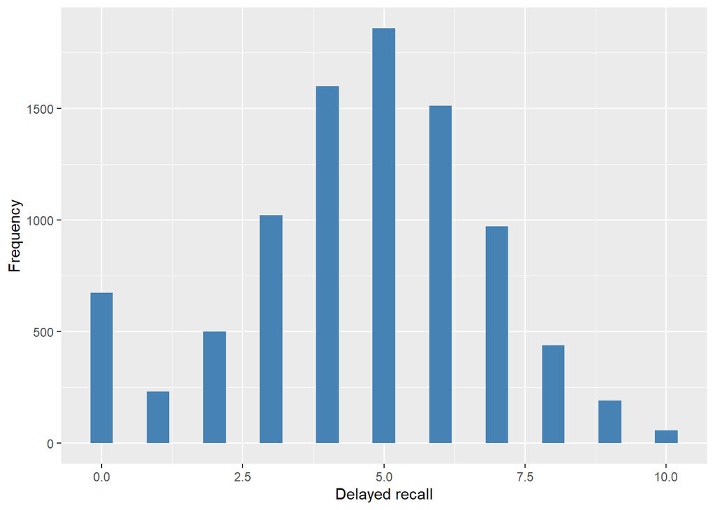

Test that assesses delayed recall using the common nouns from the list previously employed for measuring Immediate recall. Variable dichotomised by first quartil with value 0 and higher with value 1

| Sample size | Missing values |
| --- | --- |
| 9666 | 608 |

Category

|  | 0 | 1 |
| --- | --- | --- |
| Frequency | 2429.00 | 6629.00 |
| Percentage | 25.13 | 68.58 |

Type of missing

|  | 991 | 992 | 993 | 994 | 995 | 996 | 997 | 998 | 999 | NA |
| --- | --- | --- | --- | --- | --- | --- | --- | --- | --- | --- |
| Frequency | 0 | 0 | 0 | 0 | 0 | 597.00 | 11.00 | 0 | 0 | 0 |
| Percentage | 0 | 0 | 0 | 0 | 0 | 6.18 | 0.11 | 0 | 0 | 0 |

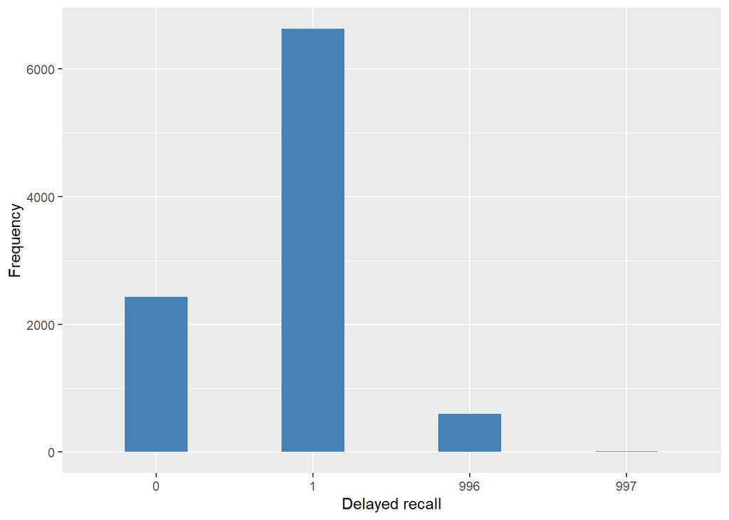

#### 2.1.7.4 Validation

Continuous vs Dichotomous

|  | 0:3->0 | 4:10->1 | -1->996 | -9->997 |
| --- | --- | --- | --- | --- |
| continuous | 2429 | 6629 | 597 | 11 |
| dichotomous | 2429 | 6629 | 597 | 11 |

## 2.2 Descriptive statistics of the harmonised variable `cog_del` accross populations and waves

Two tables are generated:

1. Percentages of categories in each harmonised variable.
2. Frequencies and percentages of individuals with different trajectories. To avoid too large table, only trajectories with percentages larger than 0.3 are shown.

Test that assesses delayed recall using the common nouns from the list previously employed for measuring Immediate recall. Variable dichotomised by first quartil with value 0 and higher with value 1

| val | label | W1 | W2 | W3 | W4 | W5 | W6 | W7 |
| --- | --- | --- | --- | --- | --- | --- | --- | --- |
| 0 | <=25% | 35.06 | 31.16 | 26.89 | 26.01 | 25.24 | 38.26 | 25.13 |
| 1 | >25% | 61.65 | 66.9 | 70.26 | 69.66 | 69.07 | 55.81 | 68.58 |
| 991 | CAPI interviewer error | 0 | 0 | 0 | 0 | 0 | 0 | 0 |
| 992 | Impute | 0 | 0 | 0 | 0 | 0 | 0 | 0 |
| 993 | Disable to measure | 0 | 0 | 0 | 0 | 0 | 0 | 0 |
| 994 | Not attempt not done | 0 | 0 | 0 | 0 | 0 | 0 | 0 |
| 995 | Does not answer | 0 | 0 | 0 | 0 | 0 | 0 | 0 |
| 996 | Not applicable | 2.44 | 1.63 | 2.77 | 4.04 | 5.23 | 5.9 | 6.18 |
| 997 | Refuse | 0.69 | 0.17 | 0.08 | 0.3 | 0.47 | 0.04 | 0.11 |
| 998 | Do not know | 0.16 | 0.14 | 0 | 0 | 0 | 0 | 0 |
| 999 | Missing | 0 | 0 | 0 | 0 | 0 | 0 | 0 |
| NA | NA | 0 | 0 | 0 | 0 | 0 | 0 | 0 |
| n | sample size | 12099 | 9432 | 9771 | 11050 | 10274 | 10601 | 9666 |

|  | val | frq | raw.prc |
| --- | --- | --- | --- |
| 1 | 0000000 | 115 | 0.62 |
| 3 | 000000NA | 79 | 0.43 |
| 9 | 00000NANA | 70 | 0.38 |
| 21 | 0000NANANA | 133 | 0.72 |
| 52 | 000NANANANA | 276 | 1.49 |
| 127 | 00NANANANANA | 389 | 2.10 |
| 169 | 010NANANANA | 56 | 0.30 |
| 202 | 0111111 | 114 | 0.62 |
| 228 | 011NANANANA | 88 | 0.48 |
| 259 | 01NANANANANA | 205 | 1.11 |
| 348 | 0NANANANANANA | 1036 | 5.60 |
| 397 | 100NANANANA | 73 | 0.39 |
| 421 | 1011101 | 56 | 0.30 |
| 424 | 1011111 | 65 | 0.35 |
| 467 | 10NANANANANA | 182 | 0.98 |
| 497 | 1101111 | 85 | 0.46 |
| 519 | 110NANANANA | 69 | 0.37 |
| 533 | 1110111 | 88 | 0.48 |
| 541 | 1111000 | 59 | 0.32 |
| 545 | 1111011 | 90 | 0.49 |
| 550 | 1111100 | 101 | 0.55 |
| 551 | 1111101 | 285 | 1.54 |
| 553 | 1111110 | 123 | 0.67 |
| 554 | 1111111 | 1522 | 8.23 |
| 555 | 111111NA | 141 | 0.76 |
| 558 | 11111NANA | 118 | 0.64 |
| 566 | 1111NANANA | 154 | 0.83 |
| 587 | 111NANANANA | 329 | 1.78 |
| 641 | 11NANANANANA | 523 | 2.83 |
| 750 | 1NANANANANANA | 1019 | 5.51 |
| 877 | NANA0NANANANA | 85 | 0.46 |
| 906 | NANA11101 | 73 | 0.39 |
| 909 | NANA11111 | 456 | 2.47 |
| 910 | NANA1111NA | 63 | 0.34 |
| 913 | NANA111NANA | 70 | 0.38 |
| 921 | NANA11NANANA | 79 | 0.43 |
| 941 | NANA1NANANANA | 245 | 1.33 |
| 942 | NANANA0000 | 103 | 0.56 |
| 955 | NANANA0111 | 58 | 0.31 |
| 966 | NANANA0NANANA | 123 | 0.67 |
| 971 | NANANA1011 | 66 | 0.36 |
| 976 | NANANA1100 | 67 | 0.36 |
| 977 | NANANA1101 | 193 | 1.04 |
| 979 | NANANA1110 | 67 | 0.36 |
| 980 | NANANA1111 | 748 | 4.05 |
| 981 | NANANA111NA | 90 | 0.49 |
| 984 | NANANA11NANA | 107 | 0.58 |
| 993 | NANANA1NANANA | 242 | 1.31 |
| 1010 | NANANANANA00 | 100 | 0.54 |
| 1011 | NANANANANA01 | 164 | 0.89 |
| 1012 | NANANANANA0NA | 90 | 0.49 |
| 1014 | NANANANANA11 | 567 | 3.07 |
| 1015 | NANANANANA1NA | 168 | 0.91 |
| 1016 | NANANANANANA0 | 110 | 0.59 |
| 1017 | NANANANANANA1 | 361 | 1.95 |
| 1018 | NANANANANANANA | 591 | 3.20 |

## 2.3 Summary of descriptive statistics of the harmonised variable `cog_del_c` accross populations and waves

Test that assesses delayed recall using the common nouns from the list previously employed for measuring Immediate recall. The total number of words correctly recalled after a delay

| cog_del_c | W1 | W2 | W3 | W4 | W5 | W6 | W7 |
| --- | --- | --- | --- | --- | --- | --- | --- |
| Min. | 0 | 0 | 0 | 0 | 0 | 0 | 0 |
| 1st Qu. | 3 | 3 | 3 | 3 | 3 | 4 | 3 |
| Median | 4 | 4 | 5 | 5 | 5 | 5 | 5 |
| Mean | 4.01 | 4.283 | 4.53 | 4.566 | 4.587 | 4.774 | 4.601 |
| 3rd Qu. | 5 | 6 | 6 | 6 | 6 | 6 | 6 |
| Max. | 10 | 10 | 10 | 10 | 10 | 10 | 10 |
| No-missings | 11701 | 9249 | 9492 | 10571 | 9689 | 9972 | 9058 |
| 991 | 0 | 0 | 0 | 0 | 0 | 0 | 0 |
| 992 | 0 | 0 | 0 | 0 | 0 | 0 | 0 |
| 993 | 0 | 0 | 0 | 0 | 0 | 0 | 0 |
| 994 | 0 | 0 | 0 | 0 | 0 | 0 | 0 |
| 995 | 0 | 0 | 0 | 0 | 0 | 0 | 0 |
| 996 | 295 | 154 | 271 | 446 | 537 | 625 | 597 |
| 997 | 84 | 16 | 8 | 33 | 48 | 4 | 11 |
| 998 | 19 | 13 | 0 | 0 | 0 | 0 | 0 |
| 999 | 0 | 0 | 0 | 0 | 0 | 0 | 0 |
| NA | 0 | 0 | 0 | 0 | 0 | 0 | 0 |
| sample size | 12099 | 9432 | 9771 | 11050 | 10274 | 10601 | 9666 |

# 3 Quality estimation

No comments